# Analisis exploratorio de dataSet ‘RR HH - Left’

Alvarez Ignacio Nicolas

Este ejercicio consiste en realizar un análisis exploratorio sobre un dataset de personal de una determinada empresa con 14999 instancias y 10 atributos.

El objetivo es conseguir un modelo adecuado con un resultado aceptable interpretando cada paso del razonamiento necesario para llegar al objetivo.

- El atributo objetivo es Left. Indica si un empleado se queda en la empresa o se va.

# 1.Carga de Librerias

# 2.Carga de Datos

# 3.Ordenamiento de Datos

# 4.Visualizacion de los datos

```r
raw_data
```

| left | salary | satisfaction_level | last_evaluation | number_project | average_montly_hours | time_spend_company | Work_accident | promotion_last_5years | sales |
| --- | --- | --- | --- | --- | --- | --- | --- | --- | --- |
| 1 | low | 0.38 | 0.53 | 2 | 157 | 3 | 0 | 0 | sales |
| 1 | medium | 0.80 | 0.86 | 5 | 262 | 6 | 0 | 0 | sales |
| 1 | medium | 0.11 | 0.88 | 7 | 272 | 4 | 0 | 0 | sales |
| 1 | low | 0.72 | 0.87 | 5 | 223 | 5 | 0 | 0 | sales |
| 1 | low | 0.37 | 0.52 | 2 | 159 | 3 | 0 | 0 | sales |
| 1 | low | 0.41 | 0.50 | 2 | 153 | 3 | 0 | 0 | sales |
| 1 | low | 0.10 | 0.77 | 6 | 247 | 4 | 0 | 0 | sales |
| 1 | low | 0.92 | 0.85 | 5 | 259 | 5 | 0 | 0 | sales |
| 1 | low | 0.89 | 1.00 | 5 | 224 | 5 | 0 | 0 | sales |
| 1 | low | 0.42 | 0.53 | 2 | 142 | 3 | 0 | 0 | sales |

[output cut: 990 more lines]

# 5.Resumen de los datos

```r
summary(raw_data)
```

```
      left           salary     satisfaction_level last_evaluation  number_project  average_montly_hours
 Min.   :0.0000   high  :1237   Min.   :0.0900     Min.   :0.3600   Min.   :2.000   Min.   : 96.0
 1st Qu.:0.0000   low   :7316   1st Qu.:0.4400     1st Qu.:0.5600   1st Qu.:3.000   1st Qu.:156.0
 Median :0.0000   medium:6446   Median :0.6400     Median :0.7200   Median :4.000   Median :200.0
 Mean   :0.2381                 Mean   :0.6128     Mean   :0.7161   Mean   :3.803   Mean   :201.1
 3rd Qu.:0.0000                 3rd Qu.:0.8200     3rd Qu.:0.8700   3rd Qu.:5.000   3rd Qu.:245.0
 Max.   :1.0000                 Max.   :1.0000     Max.   :1.0000   Max.   :7.000   Max.   :310.0

 time_spend_company Work_accident    promotion_last_5years         sales
 Min.   : 2.000     Min.   :0.0000   Min.   :0.00000       sales      :4140
 1st Qu.: 3.000     1st Qu.:0.0000   1st Qu.:0.00000       technical  :2720
 Median : 3.000     Median :0.0000   Median :0.00000       support    :2229
 Mean   : 3.498     Mean   :0.1446   Mean   :0.02127       IT         :1227
 3rd Qu.: 4.000     3rd Qu.:0.0000   3rd Qu.:0.00000       product_mng: 902
 Max.   :10.000     Max.   :1.0000   Max.   :1.00000       marketing  : 858
                                                           (Other)    :2923
```

# 6.Estructura de los datos

```r
str(raw_data)
```

```
'data.frame':   14999 obs. of  10 variables:
 $ left                 : int  1 1 1 1 1 1 1 1 1 1 ...
 $ salary               : Factor w/ 3 levels "high","low","medium": 2 3 3 2 2 2 2 2 2 2 ...
 $ satisfaction_level   : num  0.38 0.8 0.11 0.72 0.37 0.41 0.1 0.92 0.89 0.42 ...
 $ last_evaluation      : num  0.53 0.86 0.88 0.87 0.52 0.5 0.77 0.85 1 0.53 ...
 $ number_project       : int  2 5 7 5 2 2 6 5 5 2 ...
 $ average_montly_hours : int  157 262 272 223 159 153 247 259 224 142 ...
 $ time_spend_company   : int  3 6 4 5 3 3 4 5 5 3 ...
 $ Work_accident        : int  0 0 0 0 0 0 0 0 0 0 ...
 $ promotion_last_5years: int  0 0 0 0 0 0 0 0 0 0 ...
 $ sales                : Factor w/ 10 levels "accounting","hr",..: 8 8 8 8 8 8 8 8 8 8 ...
```

# 7.Análisis exploratorio

## 7,1.Revisión de datos nulos

```r
CantidadNulos <- sapply(raw_data, function(x) sum(is.na(x)))
data.frame(CantidadNulos)
```

|  | CantidadNulos |
| --- | --- |
| left | 0 |
| salary | 0 |
| satisfaction_level | 0 |
| last_evaluation | 0 |
| number_project | 0 |
| average_montly_hours | 0 |
| time_spend_company | 0 |
| Work_accident | 0 |
| promotion_last_5years | 0 |
| sales | 0 |

## 7,2.Satisfaction Level

```r
par(mfrow = c(1,2))

boxplot(raw_data$satisfaction_level, main = "Satisfaction Level")

hist(raw_data$satisfaction_level, main = "Distribucion Satisfaction Level", freq = F)
```

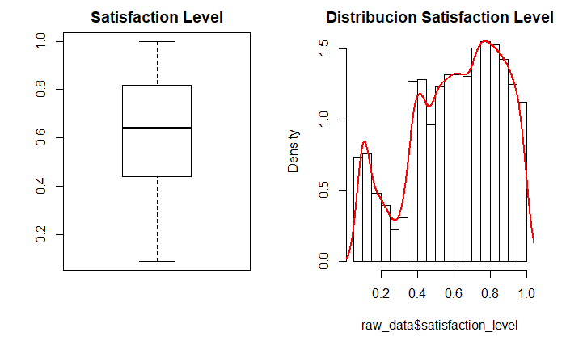

```r
lines(density(raw_data$satisfaction_level), col = "red", lwd=2)
```

- Se observa que la mayor parte de las instancias poseen un satisfaction_level entre (0.4 y 1.0).

## 7,3.Last Evaluation

```r
par(mfrow = c(1,2))

boxplot(raw_data$last_evaluation, main = "Last Evaluation")
hist(raw_data$last_evaluation, main = "Distribucion Last Evaluation", freq = F)
```

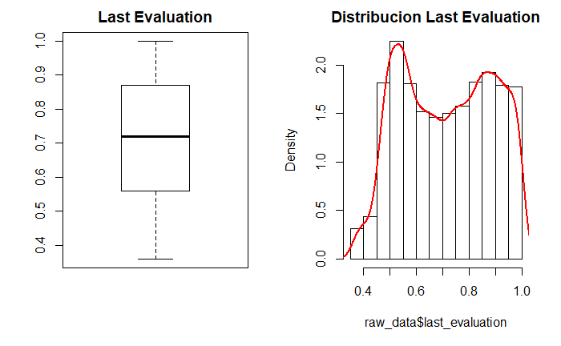

```r
lines(density(raw_data$last_evaluation), col = "red", lwd=2)
```

- Se observa que la mayor parte de las instancias poseen un valor de last_evaluation entre (0.45 y 1.0), con una mediana alrrededor de 0.7.

## 7,4.Number of Project

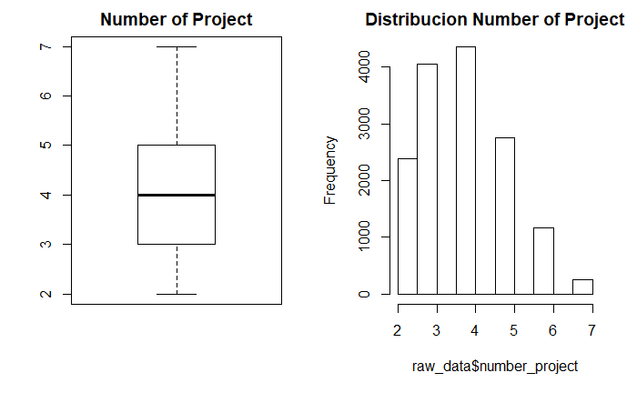

```r
par(mfrow = c(1,2))

boxplot(raw_data$number_project, main = "Number of Project")
hist(raw_data$number_project, main = "Distribucion Number of Project")
```

- Se observa que la mayor parte de las instancias poseen un valor de number_project entre (2, 5), con una mediana alrrededor de 4.

## 7,5.Average Montly Hours

```r
par(mfrow = c(1,2))

boxplot(raw_data$average_montly_hours, main = "Average Montly Hours")
hist(raw_data$average_montly_hours, main = "Distribucion Average Montly Hours", freq = F)
```

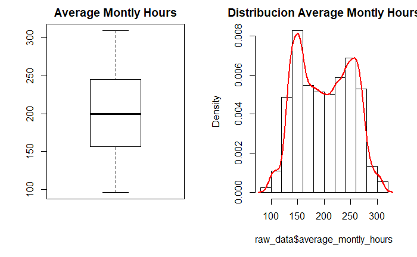

```r
lines(density(raw_data$average_montly_hours), col = "red", lwd=2)
```

- Se observa que la mayor parte de las instancias poseen un valor de average_montly_hours entre (125, 275), con una mediana alrrededor de 200.

## 7,6.Time Spend Company

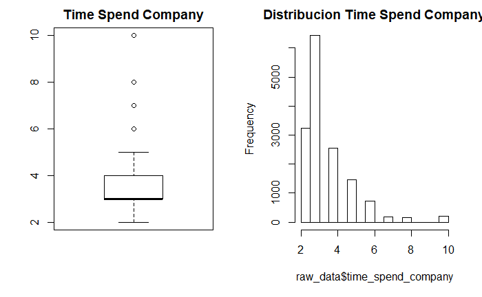

```r
par(mfrow = c(1,2))

boxplot(raw_data$time_spend_company, main = "Time Spend Company")
hist(raw_data$time_spend_company, main = "Distribucion Time Spend Company")
```

- Se observa que la mayor parte de las instancias poseen un valor de time_spend_company entre (2, 6), con una mediana alrrededor de 3, y un valor minimo de 2. Se presentan valores atipicos para valores superiores a 5.

## 7,7.Salary

```r
colorSalary = rainbow(nlevels((as.factor(raw_data$salary))))
colorYN = rainbow(nlevels((as.factor(raw_data$Work_accident))))
colorSales = rainbow(nlevels((as.factor(raw_data$sales))))
```

## 7,8.Salary y Promotion

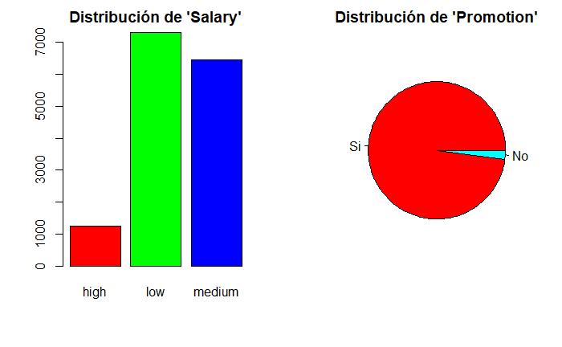

```r
par(mfrow = c(1,2))

barplot(summary(raw_data$salary), main = "Distribución de 'Salary'",
        col= colorSalary )
pie(summary(as.factor(raw_data$promotion_last_5years)), labels = c("Si","No"), main = "Distribución de 'Promotion'", col=colorYN)
```

## 7,9.Work Accident y Distribución de Left

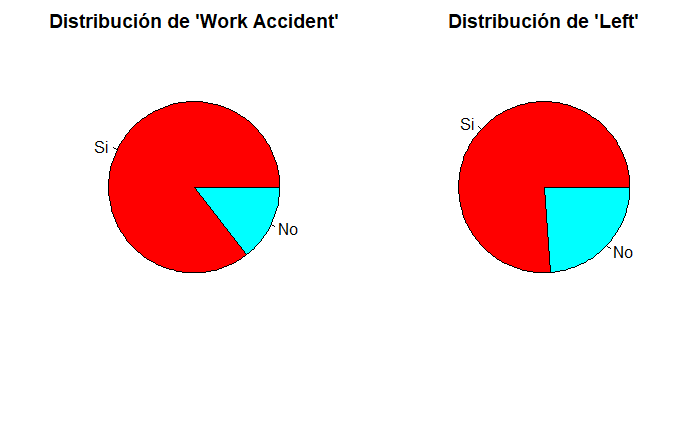

```r
par(mfrow = c(1,2))
pie(summary(as.factor(raw_data$Work_accident)), labels = c("Si","No"), main = "Distribución de 'Work Accident'", col=colorYN)
pie(summary(as.factor(raw_data$left)), labels = c("Si","No"), main = "Distribución de 'Left'", col=colorYN)
```

## 7,10.Sales

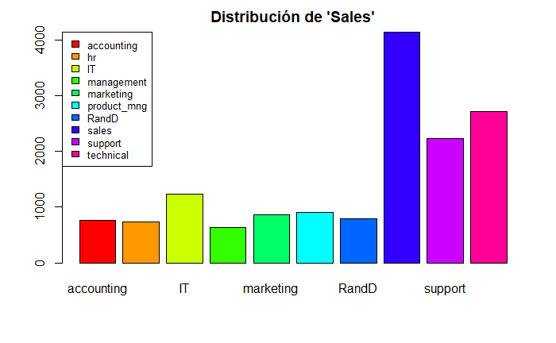

```r
barplot(summary(raw_data$sales), main = "Distribución de 'Sales'", col = colorSales)
legend("topleft", summary(raw_data$sales), cex = 0.8,  fill = colorSales, legend=levels(raw_data$sales))
```

# 8.Estudio de Variables

## 8,1.Correlación raw_data

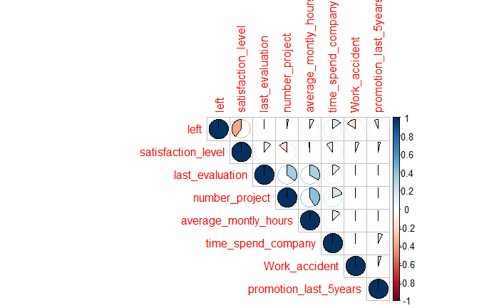

```r
corrplot(cor(select(raw_data, -c("salary", "sales"))), type="upper", method="pie")
```

```r
cor(select(raw_data, -c("salary", "sales")))
```

```
                             left satisfaction_level last_evaluation number_project average_montly_hours
left                   1.00000000        -0.38837498     0.006567120    0.023787185          0.071287179
satisfaction_level    -0.38837498         1.00000000     0.105021214   -0.142969586         -0.020048113
last_evaluation        0.00656712         0.10502121     1.000000000    0.349332589          0.339741800
number_project         0.02378719        -0.14296959     0.349332589    1.000000000          0.417210634
average_montly_hours   0.07128718        -0.02004811     0.339741800    0.417210634          1.000000000
time_spend_company     0.14482217        -0.10086607     0.131590722    0.196785891          0.127754910
Work_accident         -0.15462163         0.05869724    -0.007104289   -0.004740548         -0.010142888
promotion_last_5years -0.06178811         0.02560519    -0.008683768   -0.006063958         -0.003544414
                      time_spend_company Work_accident promotion_last_5years
left                         0.144822175  -0.154621634          -0.061788107
satisfaction_level          -0.100866073   0.058697241           0.025605186
last_evaluation              0.131590722  -0.007104289          -0.008683768
number_project               0.196785891  -0.004740548          -0.006063958
average_montly_hours         0.127754910  -0.010142888          -0.003544414
time_spend_company           1.000000000   0.002120418           0.067432925
Work_accident                0.002120418   1.000000000           0.039245435
promotion_last_5years        0.067432925   0.039245435           1.000000000
```

- Aparentemente el atributo objetivo **left** se encuentra relacionado principalmente con los atributos **satisfaction_level, time_spend_company, y work_accident**.

## 8,2.Colinealidad raw_data

```r
imcdiag(select(raw_data, -c("left","salary", "sales")), raw_data$left)
```

```
Call:
imcdiag(x = select(raw_data, -c("left", "salary", "sales")),
    y = raw_data$left)


All Individual Multicollinearity Diagnostics Result

                         VIF    TOL       Wi        Fi Leamer   CVIF Klein
satisfaction_level    1.0634 0.9404 158.4444  190.1460 0.9697 1.0801     0
last_evaluation       1.2405 0.8061 600.9249  721.1580 0.8978 1.2600     1
number_project        1.3524 0.7394 880.6199 1056.8143 0.8599 1.3737     1
average_montly_hours  1.2790 0.7819 697.0355  836.4983 0.8842 1.2990     1
time_spend_company    1.0605 0.9429 151.2186  181.4744 0.9710 1.0772     0
Work_accident         1.0053 0.9948  13.1418   15.7712 0.9974 1.0210     0
promotion_last_5years 1.0076 0.9925  18.9554   22.7480 0.9962 1.0234     0

1 --> COLLINEARITY is detected by the test
0 --> COLLINEARITY is not detected by the test

* all coefficients have significant t-ratios

R-square of y on all x: 0.1927

* use method argument to check which regressors may be the reason of collinearity
===================================
```

- Ss posible que exista colinealidad vinculado con los atributos **last_evaluation, number_project, average_montly_hours** .

## 8,3.Estudio de Satisfaction_level

### 8,3,1.Satisfaction_level vs Last_evaluation

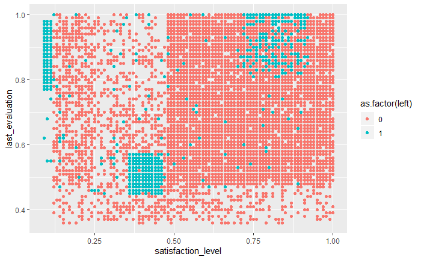

```r
ggplot(raw_data,
       aes(x = satisfaction_level, y = last_evaluation, color = as.factor(left))) + geom_point()
```

- Mediante este scatterplot se ve la relacion entre dos variables continuas: **satisfaction_level y last_evaluation**.
- El estudio se realizará particularmente sobre las instancias cuyo valor de left sea 0, es decir sobre aquellos empleados que conserva la empresa. Se distingue para esto la poblacion cuyo satisfaction_level **es mayor a 0.50** y cuyo valor de last_evaluation **es mayor a 0.45**.
- Cabe considerar que aquellas concentraciones de puntos con valor de left 1 (figura [(0.4, 0.45),(0.48, 0.45),(0.4, 0.58),(0.48, 0.58)] y figura [(0.1, 0.75),(0.15, 0.75),(0.1, 0.95),(0.15, 0.95)]) pueden corresponder a casos de individuos muy capacitados pero poco satisfechos o individuos poco satisfechos y con un bajo desempeño en su ultima evaluacion.

### 8,3,2.Satisfaction_level vs Number_projects

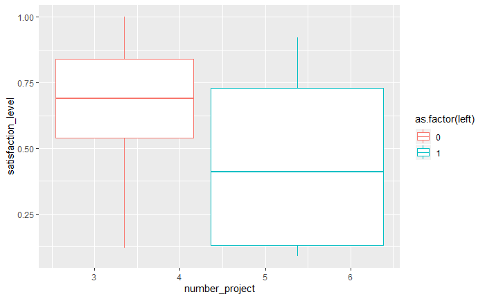

```r
ggplot(raw_data,
       aes(x = number_project, y = satisfaction_level, color = as.factor(left))) + geom_boxplot()
```

- Se observa que aquellas instancias con una cantidad de proyectos superiores a 4 y con niveles de conformidad entre 0.10 y 0.70, presentan la mayoria de las salidas de la empresa.
- Se observa que aquellas instancias con una cantidad de proyectos menores a 4, presentan una mayoria con niveles de satisfaccion entre 0.50 y 0.80.

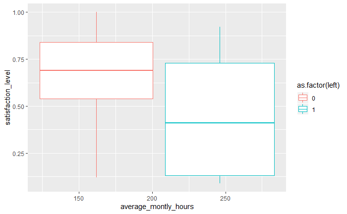

```r
ggplot(raw_data,
       aes(x = average_montly_hours, y = satisfaction_level, color = as.factor(left))) + geom_boxplot()
```

- Se observa que la mayoria de los indiviuos que dejan la empresa mantenian una media de horas mensuales superiores a las 200 horas, posiblemente se relacione con el alto numero de proyectos en los que participaban.

### 8,3,4.Satisfaction_level vs Time_Spend_in_Company(años)

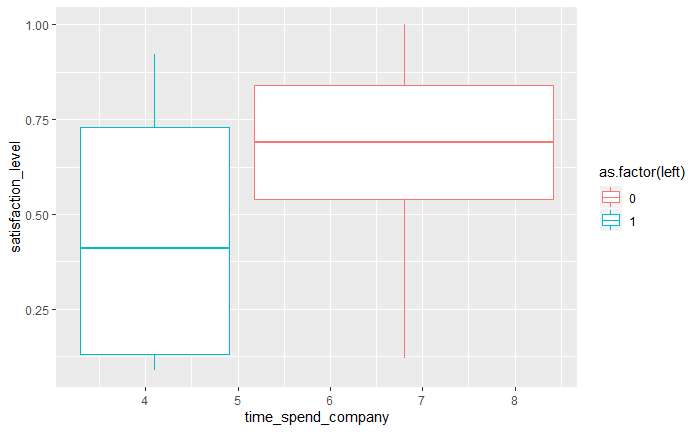

```r
ggplot(raw_data,
       aes(x = time_spend_company, y = satisfaction_level, color = as.factor(left))) + geom_boxplot()
```

- La mayoria de los empleados que abandonaron la empresa, estuvieron menos de 5 años en la compañia, y mantuvieron un nivel de satisfaccion con una mediana de alrrededor de 0.45.

# 9.Modelos con Raw Data

## 9,1.Conjunto de datos de Entrenamiento y Prueba

```r
data_train_1 <- sample_frac(raw_data, 0.7)
prop.table(table(data_train_1$left))
```

```
        0         1
0.7590247 0.2409753
```

```r
data_test_1 <- setdiff(raw_data, data_train_1)
prop.table(table(data_test_1$left))
```

```
        0         1
0.8801029 0.1198971
```

```r
data_train_1$left <- factor(data_train_1$left)
data_test_1$left <- factor(data_test_1$left)
```

## 9,2.Modelo de Arbol de Decision

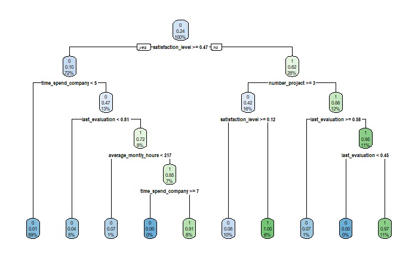

```r
tree_1 <- rpart(formula = left ~ ., data = data_train_1)
rpart.plot(tree_1)
```

```r
prediccion <- predict(tree_1, newdata = data_test_1, type = "class")
confusionMatrix(prediccion, data_test_1[["left"]])
```

```
Confusion Matrix and Statistics

          Reference
Prediction    0    1
         0 2708   29
         1   30  344

               Accuracy : 0.981
                 95% CI : (0.9756, 0.9855)
    No Information Rate : 0.8801
    P-Value [Acc > NIR] : <2e-16

                  Kappa : 0.9102

 Mcnemar's Test P-Value : 1

            Sensitivity : 0.9890
            Specificity : 0.9223
         Pos Pred Value : 0.9894
         Neg Pred Value : 0.9198
             Prevalence : 0.8801
         Detection Rate : 0.8705
   Detection Prevalence : 0.8798
      Balanced Accuracy : 0.9556

       'Positive' Class : 0
```

## 9,3.Regresión Logistica

```r
glm.model <- glm(formula = left ~ ., data = data_train_1, family = binomial(logit))
summary(glm.model)
```

```
Call:
glm(formula = left ~ ., family = binomial(logit), data = data_train_1)

Deviance Residuals:
    Min       1Q   Median       3Q      Max
-2.3066  -0.6690  -0.4022  -0.1078   3.0220

Coefficients:
                        Estimate Std. Error z value Pr(>|z|)
(Intercept)           -1.3546828  0.2280553  -5.940 2.85e-09 ***
salarylow              1.8941971  0.1511511  12.532  < 2e-16 ***
salarymedium           1.3888745  0.1520547   9.134  < 2e-16 ***
satisfaction_level    -4.1580605  0.1168443 -35.586  < 2e-16 ***
last_evaluation        0.6592715  0.1781232   3.701 0.000215 ***
number_project        -0.3017375  0.0254097 -11.875  < 2e-16 ***
average_montly_hours   0.0043428  0.0006187   7.020 2.22e-12 ***
time_spend_company     0.2880462  0.0187221  15.385  < 2e-16 ***
Work_accident         -1.5825269  0.1083561 -14.605  < 2e-16 ***
promotion_last_5years -1.6161117  0.3120835  -5.178 2.24e-07 ***
saleshr                0.1587844  0.1548761   1.025 0.305252
salesIT               -0.2104590  0.1436538  -1.465 0.142909
salesmanagement       -0.4990663  0.1932009  -2.583 0.009790 **
salesmarketing        -0.1203607  0.1571524  -0.766 0.443745
salesproduct_mng      -0.2351966  0.1533708  -1.534 0.125149
salesRandD            -0.7177087  0.1727671  -4.154 3.26e-05 ***
salessales            -0.1145991  0.1207182  -0.949 0.342463
salessupport          -0.0620536  0.1287843  -0.482 0.629919
salestechnical        -0.0922945  0.1262020  -0.731 0.464581
---
Signif. codes:  0 ‘***’ 0.001 ‘**’ 0.01 ‘*’ 0.05 ‘.’ 0.1 ‘ ’ 1

(Dispersion parameter for binomial family taken to be 1)

    Null deviance: 11595.1  on 10498  degrees of freedom
Residual deviance:  9038.5  on 10480  degrees of freedom
AIC: 9076.5

Number of Fisher Scoring iterations: 5
```

```r
lgm.predict <- round(predict(glm.model, data_test_1, type = "response"))
lgm.predict <- factor(lgm.predict)
confusionMatrix(lgm.predict, data_test_1$left)
```

```
Confusion Matrix and Statistics

          Reference
Prediction    0    1
         0 2542  231
         1  196  142

               Accuracy : 0.8627
                 95% CI : (0.8502, 0.8747)
    No Information Rate : 0.8801
    P-Value [Acc > NIR] : 0.99844

                  Kappa : 0.3222

 Mcnemar's Test P-Value : 0.09989

            Sensitivity : 0.9284
            Specificity : 0.3807
         Pos Pred Value : 0.9167
         Neg Pred Value : 0.4201
             Prevalence : 0.8801
         Detection Rate : 0.8171
   Detection Prevalence : 0.8914
      Balanced Accuracy : 0.6546

       'Positive' Class : 0
```

## 9,4.Random Forest

```r
rf.model <- randomForest(left~., data = data_train_1)
```

```r
rf.prediction <- predict(rf.model, data_test_1, type = "class")
confusionMatrix(rf.prediction, data_test_1$left)
```

```
Confusion Matrix and Statistics

          Reference
Prediction    0    1
         0 2733   29
         1    5  344

               Accuracy : 0.9891
                 95% CI : (0.9848, 0.9924)
    No Information Rate : 0.8801
    P-Value [Acc > NIR] : < 2.2e-16

                  Kappa : 0.9467

 Mcnemar's Test P-Value : 7.998e-05

            Sensitivity : 0.9982
            Specificity : 0.9223
         Pos Pred Value : 0.9895
         Neg Pred Value : 0.9857
             Prevalence : 0.8801
         Detection Rate : 0.8785
   Detection Prevalence : 0.8878
      Balanced Accuracy : 0.9602

       'Positive' Class : 0
```

## 9,5.LDA

```r
lda.model <- train(left ~., data = data_train_1, method = "lda")
lda.predict <- predict(lda.model, data_test_1)
confusionMatrix(lda.predict, data_test_1$left)
```

```
Confusion Matrix and Statistics

          Reference
Prediction    0    1
         0 2517  239
         1  221  134

               Accuracy : 0.8521
                 95% CI : (0.8392, 0.8644)
    No Information Rate : 0.8801
    P-Value [Acc > NIR] : 1.000

                  Kappa : 0.2845

 Mcnemar's Test P-Value : 0.428

            Sensitivity : 0.9193
            Specificity : 0.3592
         Pos Pred Value : 0.9133
         Neg Pred Value : 0.3775
             Prevalence : 0.8801
         Detection Rate : 0.8091
   Detection Prevalence : 0.8859
      Balanced Accuracy : 0.6393

       'Positive' Class : 0
```

A fin de poder evaluar los modelos se utilizan los siguientes valores resultado:

- Matriz de Confusion: Matriz que permite comparar los valores obtenidos durante la prueba y entrenamiento en las predicciones, los valores que se muestran corresponden a: **verdaderos positivo** (es la cantidad de positivos que fueron clasificados correctamente como positivos por el modelo), **verdaderos negativos** (es la cantidad de negativos que fueron clasificados correctamente como negativos por el modelo), **falsos negativos** (es la cantidad de positivos que fueron clasificados incorrectamente como negativos) y **falsos positivos** (es la cantidad de negativos que fueron clasificados incorrectamente como positivos).

## 9,6.Iteración sobre los modelos

```r
results_tree <- matrix(nrow=10,ncol=1)
for (i in 1:10){

   data_train_1 <- sample_frac(raw_data, 0.7)
   prop.table(table(data_train_1$left))

   data_test_1 <- setdiff(raw_data, data_train_1)
   prop.table(table(data_test_1$left))

   data_train_1$left <- factor(data_train_1$left)
   data_test_1$left <- factor(data_test_1$left)

   tree_1 <- rpart(formula = left ~ ., data = data_train_1)
   prediccion <- predict(tree_1, newdata = data_test_1, type = "class")
   res_tree <- confusionMatrix(prediccion, data_test_1[["left"]])
   results_tree[i,] <- res_tree$overall["Accuracy"]
}
```

- Se obtiene la media de 10 observaciones del modelo para una posterior comparación del Accuracy del Modelo.

```r
results_log <- matrix(nrow=10,ncol=1)
for (i in 1:10){

   data_train_1 <- sample_frac(raw_data, 0.7)
   prop.table(table(data_train_1$left))

   data_test_1 <- setdiff(raw_data, data_train_1)
   prop.table(table(data_test_1$left))

   data_train_1$left <- factor(data_train_1$left)
   data_test_1$left <- factor(data_test_1$left)

   glm.model <- glm(formula = left ~ ., data = data_train_1, family = "binomial")
   lgm.predict <- round(predict(glm.model, data_test_1, type = "response"))
   lgm.predict <- factor(lgm.predict)
   res_lgm = confusionMatrix(lgm.predict, data_test_1$left)
   results_log[i,] <- res_lgm$overall["Accuracy"]
}
```

- Se obtiene la media de 10 observaciones del modelo para una posterior comparación del Accuracy del Modelo.

```r
results_rf <- matrix(nrow=10,ncol=1)
for (i in 1:10){

   data_train_1 <- sample_frac(raw_data, 0.7)
   prop.table(table(data_train_1$left))

   data_test_1 <- setdiff(raw_data, data_train_1)
   prop.table(table(data_test_1$left))

   data_train_1$left <- factor(data_train_1$left)
   data_test_1$left <- factor(data_test_1$left)

   rf.model <- randomForest(left~., data = data_train_1)
   rf.prediction <- predict(rf.model, data_test_1, type = "class")
   res_random = confusionMatrix(rf.prediction, data_test_1$left)
   results_rf[i,] <- res_random$overall["Accuracy"]
}
```

- Se obtiene la media de 10 observaciones del modelo para una posterior comparación del Accuracy del Modelo.

```r
results_lda <- matrix(nrow=10,ncol=1)
for (i in 1:10){

   data_train_1 <- sample_frac(raw_data, 0.7)
   prop.table(table(data_train_1$left))

   data_test_1 <- setdiff(raw_data, data_train_1)
   prop.table(table(data_test_1$left))

   data_train_1$left <- factor(data_train_1$left)
   data_test_1$left <- factor(data_test_1$left)

   lda.model <- train(left ~., data = data_train_1, method = "lda")
   lda.predict <- predict(lda.model, data_test_1)
   res_lda = confusionMatrix(lda.predict, data_test_1$left)

   results_lda[i,] <- res_lda$overall["Accuracy"]
}
```

[output not shown]

# 10.Limpieza de datos

```r
data_set <- raw_data
data_set <- dummy_cols(data_set, select_columns = c("sales"))
data_set$sales = NULL

data_set <- dummy_cols(data_set, select_columns = c("salary"))
data_set$salary = NULL
```

- Dada la naturaleza de los atributos sales y salary (factores char), se procede a realizar un proceso de encoding para su posterior manipulacion. Se elimina la columna original a fin de evitar problemas de colinealidad.

```r
data_set <- data_set %>% filter(satisfaction_level > 0.48) %>% filter(last_evaluation > 0.50)
```

- En la observacion de **satisfaction_level vs last_evaluation** se resolvio trabajar sobre la mayor concentracion de empleados que permanecen en la organización.

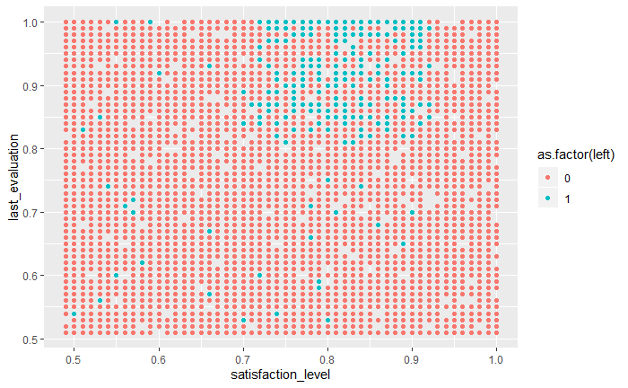

```r
ggplot(data_set,
       aes(x = satisfaction_level, y = last_evaluation, color = as.factor(left))) + geom_point()
```

## 10,1.Matriz de correlación

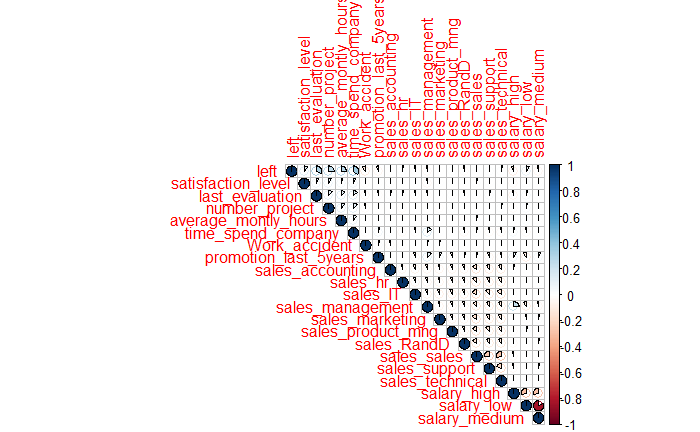

```r
corrplot(cor(data_set), type="upper", method="pie")
```

- Aparentemente la variable left se encuentra principalmente relacionada con **satisfaction_level, last_evaluation, number_project, average_montly_hours y time_spend_company**.

```r
imcdiag(data_set, data_set$left)
```

```
Call:
imcdiag(x = data_set, y = data_set$left)


All Individual Multicollinearity Diagnostics Result

                         VIF    TOL       Wi       Fi Leamer CVIF Klein
left                  1.4331 0.6978 211.5604 222.7179 0.8353    0     0
satisfaction_level    1.0209 0.9795  10.2101  10.7486 0.9897    0     0
last_evaluation       1.1213 0.8918  59.2678  62.3935 0.9443    0     0
number_project        1.0763 0.9291  37.2578  39.2228 0.9639    0     0
average_montly_hours  1.0875 0.9195  42.7347  44.9885 0.9589    0     0
time_spend_company    1.1922 0.8388  93.8901  98.8419 0.9158    0     0
Work_accident         1.0143 0.9859   6.9662   7.3336 0.9929    0     0
promotion_last_5years 1.0349 0.9663  17.0316  17.9298 0.9830    0     0
sales_accounting         Inf 0.0000      Inf      Inf 0.0000  NaN     0
sales_hr                 Inf 0.0000      Inf      Inf 0.0000  NaN     0
sales_IT                 Inf 0.0000      Inf      Inf 0.0000  NaN     0
sales_management         Inf 0.0000      Inf      Inf 0.0000  NaN     0
sales_marketing          Inf 0.0000      Inf      Inf 0.0000  NaN     0
sales_product_mng        Inf 0.0000      Inf      Inf 0.0000  NaN     0
sales_RandD              Inf 0.0000      Inf      Inf 0.0000  NaN     0
sales_sales              Inf 0.0000      Inf      Inf 0.0000  NaN     0
sales_support            Inf 0.0000      Inf      Inf 0.0000  NaN     0
sales_technical          Inf 0.0000      Inf      Inf 0.0000  NaN     0
salary_high              Inf 0.0000      Inf      Inf 0.0000  NaN     0
salary_low               Inf 0.0000      Inf      Inf 0.0000  NaN     0
salary_medium            Inf 0.0000      Inf      Inf 0.0000  NaN     0

1 --> COLLINEARITY is detected by the test
0 --> COLLINEARITY is not detected by the test

satisfaction_level , last_evaluation , number_project , average_montly_hours , time_spend_company , Work_accident , promotion_last_5years , sales_accounting , sales_hr , sales_IT , sales_management , sales_marketing , sales_product_mng , sales_RandD , sales_sales , sales_support , sales_technical , …

R-square of y on all x: 1

* use method argument to check which regressors may be the reason of collinearity
===================================
```

- Se detectan variables con un alto valor de VIF, aquellas variables procedentes del proceso de encoding, aparentemente no aportan mucha relevancia al modelo y se decide excluirlas del mismo.

```r
models <- regsubsets(left~., data = data_set, nvmax = 5)
```

```
2  linear dependencies found
```

```
Reordering variables and trying again:
```

```r
summary(models)
```

[output not shown]

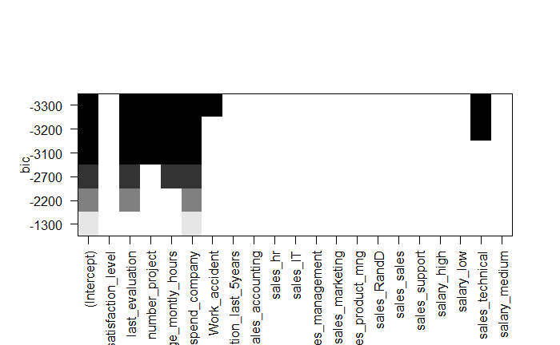

```r
plot(models)
```

```r
data_set_1 <- select(data_set, c("left", "satisfaction_level", "last_evaluation", "number_project", "average_montly_hours", "time_spend_company", "Work_accident"))

dim(data_set_1)/dim(raw_data)
```

```
[1] 0.6527102 0.7000000
```

- Tras la limpieza de los datos, se recorto el dataset original en un **35%**.

## 10,2.Matriz de correlación

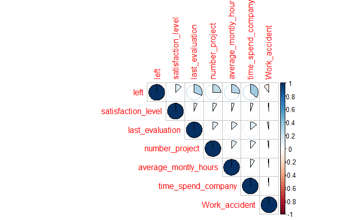

```r
corrplot(cor(data_set_1), type="upper", method="pie")
```

```r
imcdiag(data_set_1, data_set_1$left)
```

```
Call:
imcdiag(x = data_set_1, y = data_set_1$left)


All Individual Multicollinearity Diagnostics Result

                        VIF    TOL       Wi       Fi Leamer CVIF Klein
left                 1.4014 0.7135 654.5625 785.5553 0.8447    0     0
satisfaction_level   1.0195 0.9808  31.8390  38.2107 0.9904    0     0
last_evaluation      1.1180 0.8945 192.4022 230.9063 0.9458    0     0
number_project       1.0749 0.9303 122.0834 146.5151 0.9645    0     0
average_montly_hours 1.0860 0.9208 140.3014 168.3789 0.9596    0     0
time_spend_company   1.1487 0.8705 242.4752 291.0000 0.9330    0     0
Work_accident        1.0121 0.9880  19.7275  23.6755 0.9940    0     0

1 --> COLLINEARITY is detected by the test
0 --> COLLINEARITY is not detected by the test

satisfaction_level , last_evaluation , number_project , average_montly_hours , time_spend_company , Work_accident , coefficient(s) are non-significant may be due to multicollinearity

R-square of y on all x: 1

* use method argument to check which regressors may be the reason of collinearity
===================================
```

- No se observan rastros de colinealidad, dado que el valor de VIF es cercado a 1.

```r
results_tree <- matrix(nrow=10,ncol=1)
for (i in 1:10){

   data_train_2 <- sample_frac(data_set_1, 0.7)
   prop.table(table(data_train_2$left))

   data_test_2 <- setdiff(data_set_1, data_train_2)
   prop.table(table(data_test_2$left))

   data_train_2$left <- factor(data_train_2$left)
   data_test_2$left <- factor(data_test_2$left)

   tree_1 <- rpart(formula = left ~ ., data = data_train_2)
   prediccion <- predict(tree_1, newdata = data_test_2, type = "class")
   res_tree <- confusionMatrix(prediccion, data_test_2[["left"]])

   results_tree[i,] <- res_tree$overall["Accuracy"]
}
```

```r
results_log <- matrix(nrow=10,ncol=1)
for (i in 1:10){

   data_train_2 <- sample_frac(data_set_1, 0.7)
   prop.table(table(data_train_2$left))

   data_test_2 <- setdiff(data_set_1, data_train_2)
   prop.table(table(data_test_2$left))

   data_train_2$left <- factor(data_train_2$left)
   data_test_2$left <- factor(data_test_2$left)

   glm.model <- glm(formula = left ~ ., data = data_train_2, family = "binomial")
   lgm.predict <- round(predict(glm.model, data_test_2, type = "response"))
   lgm.predict <- factor(lgm.predict)
   res_lgm = confusionMatrix(lgm.predict, data_test_2$left)
   results_log[i,] <- res_lgm$overall["Accuracy"]
}
```

```r
results_rf <- matrix(nrow=10,ncol=1)
for (i in 1:10){

   data_train_2 <- sample_frac(data_set_1, 0.7)
   prop.table(table(data_train_2$left))

   data_test_2 <- setdiff(data_set_1, data_train_2)
   prop.table(table(data_test_2$left))

   data_train_2$left <- factor(data_train_2$left)
   data_test_2$left <- factor(data_test_2$left)

   rf.model <- randomForest(left~., data = data_train_2)
   rf.prediction <- predict(rf.model, data_test_2, type = "class")
   res_random = confusionMatrix(rf.prediction, data_test_2$left)
   results_rf[i,] <- res_random$overall["Accuracy"]
}
```

```r
results_lda <- matrix(nrow=10,ncol=1)
for (i in 1:10){

   data_train_2 <- sample_frac(data_set_1, 0.7)
   prop.table(table(data_train_2$left))

   data_test_2 <- setdiff(data_set_1, data_train_2)
   prop.table(table(data_test_2$left))

   data_train_2$left <- factor(data_train_2$left)
   data_test_2$left <- factor(data_test_2$left)

   lda.model <- train(left ~., data = data_train_2, method = "lda")
   lda.predict <- predict(lda.model, data_test_2)
   res_lda = confusionMatrix(lda.predict, data_test_2$left)

   results_lda[i,] <- res_lda$overall["Accuracy"]
}
```

## 10,3.Accuracy

| Arbol de Decision | Regresion Logistica | Random Forest | LDA |
| --- | --- | --- | --- |
| 0.9889021 | 0.9701466 | 0.9910586 | 0.971527 |

**Tras la limpieza de datos y seleccion de variables se obtuvieron valores aceptables de accuracy**. Sin embargo deben evaluarse los modelos en forma individual para seleccionar el modelo mas adecuado.